# Principal Component Analysis

# Support Vector Machines

#### Read the input file 'diabetes.csv' using Pandas and check it's column names

```python
import pandas as pd
import numpy as np
from sklearn import svm
import matplotlib.pyplot as plt

import matplotlib.pyplot as plt
import seaborn as sns
%matplotlib inline


missing_values = ["n/a", "na", "--", "?" ]
diab_df = pd.read_csv("diabetes.csv",na_values = missing_values)

diab_df.columns
diab_df.dtypes
diab_df.info()
missing_values= diab_df.columns[diab_df.isnull().any()]
print(diab_df[missing_values].isnull().sum())
```

```
<class 'pandas.core.frame.DataFrame'>
RangeIndex: 768 entries, 0 to 767
Data columns (total 9 columns):
Pregnancies                 768 non-null int64
Glucose                     768 non-null int64
BloodPressure               768 non-null int64
SkinThickness               768 non-null int64
Insulin                     768 non-null int64
BMI                         768 non-null float64
DiabetesPedigreeFunction    768 non-null float64
Age                         768 non-null int64
Outcome                     768 non-null int64
dtypes: float64(2), int64(7)
memory usage: 54.1 KB
Series([], dtype: float64)
```

#### Do correlation analysis using heatmap

```python
diab_df.describe().T
```

|  | count | mean | std | min | 25% | 50% | 75% | max |
| --- | --- | --- | --- | --- | --- | --- | --- | --- |
| Pregnancies | 768.0 | 3.845052 | 3.369578 | 0.000 | 1.00000 | 3.0000 | 6.00000 | 17.00 |
| Glucose | 768.0 | 120.894531 | 31.972618 | 0.000 | 99.00000 | 117.0000 | 140.25000 | 199.00 |
| BloodPressure | 768.0 | 69.105469 | 19.355807 | 0.000 | 62.00000 | 72.0000 | 80.00000 | 122.00 |
| SkinThickness | 768.0 | 20.536458 | 15.952218 | 0.000 | 0.00000 | 23.0000 | 32.00000 | 99.00 |
| Insulin | 768.0 | 79.799479 | 115.244002 | 0.000 | 0.00000 | 30.5000 | 127.25000 | 846.00 |
| BMI | 768.0 | 31.992578 | 7.884160 | 0.000 | 27.30000 | 32.0000 | 36.60000 | 67.10 |
| DiabetesPedigreeFunction | 768.0 | 0.471876 | 0.331329 | 0.078 | 0.24375 | 0.3725 | 0.62625 | 2.42 |
| Age | 768.0 | 33.240885 | 11.760232 | 21.000 | 24.00000 | 29.0000 | 41.00000 | 81.00 |
| Outcome | 768.0 | 0.348958 | 0.476951 | 0.000 | 0.00000 | 0.0000 | 1.00000 | 1.00 |

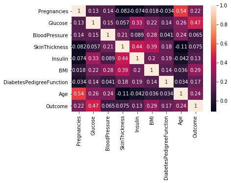

```python
sns.heatmap(diab_df.corr(),annot = True)
```

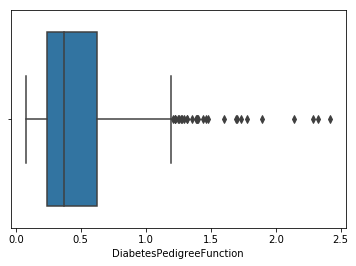

```python
sns.boxplot(diab_df['DiabetesPedigreeFunction'])
```

```python
diab_df.mean()


diab_df.median()
```

[output not shown]

```python
##Imputing zero with meaningful data

def impute_mean(col):
    if pd.isnull(col[0]):
        return 120
    else:
        return col
##dia['Bare Nuclei']=df_pca['Bare Nuclei'].apply(impute_Bare)
```

```python
#diab_df['Glucose']=diab_df[['Glucose']].apply(impute_mean)
diab_df['Glucose']=diab_df['Glucose'].replace(0,120)
diab_df['SkinThickness']=diab_df['SkinThickness'].replace(0,20)
diab_df['Insulin']=diab_df['Insulin'].replace(0,79)
diab_df['BloodPressure']=diab_df['BloodPressure'].replace(69,72)
diab_df['BMI']=diab_df['BMI'].replace(0,31)
diab_df.iloc[2]
```

```
Pregnancies                   8.000
Glucose                     183.000
BloodPressure                64.000
SkinThickness                20.000
Insulin                      79.000
BMI                          23.300
DiabetesPedigreeFunction      0.672
Age                          32.000
Outcome                       1.000
Name: 2, dtype: float64
```

#### Split the dataset and Scale the data points using MinMaxScaler

```python
from sklearn import preprocessing
from sklearn.preprocessing import MinMaxScaler

#scaler = preprocessing.MinMaxScaler()

target = diab_df["Outcome"]
features = diab_df.drop(["Outcome"], axis=1)

scaler = MinMaxScaler()
scaled_X_train_df = scaler.fit_transform(features)
#scaled_y_train_df = scaler.fit_transform(y_train)

from sklearn.model_selection import train_test_split

# To calculate the accuracy score of the model
from sklearn.metrics import accuracy_score, confusion_matrix



X_train, X_test, y_train, y_test = train_test_split(scaled_X_train_df,target, test_size = 0.2, random_state = 10)
```

#### Train Support Vector Machine Model

```python
from sklearn.svm import SVC

# Building a Support Vector Machine on train data
svc_model = SVC(C= .1, kernel='linear', gamma= 1)
svc_model.fit(X_train, y_train)

prediction = svc_model.predict(X_test)
```

```python
# check the accuracy on the training set
print(svc_model.score(X_train, y_train))
print(svc_model.score(X_test, y_test))
```

```
0.762214983713355
0.6948051948051948
```

## Popularity based Recommendation systems

### About Dataset

Anonymous Ratings on jokes.

1. Ratings are real values ranging from -10.00 to +10.00 (the value "99" corresponds to "null" = "not rated").
2. One row per user
3. The first column gives the number of jokes rated by that user. The next 100 columns give the ratings for jokes 01 - 100.

### Read the dataset(jokes.csv).

Check whether you file has header or not in it. If there is no header, then use header=none while reading the dataset

```python
import pandas as pd
joke_file_rd=pd.read_csv('jokes.csv',sep=',',header=0)
```

### Consider `ratings` named dataframe with only first 200 rows and all columns from 1(first column is 0) of dataset

```python
ratings_all=pd.DataFrame(joke_file_rd.head(200))
print(ratings_all.shape)
#
ratings=ratings_all.iloc[:,1:]
print(ratings.shape)
ratings.head()
```

```
(200, 101)
(200, 100)
```

|  | Joke1 | Joke2 | Joke3 | Joke4 | Joke5 | Joke6 | Joke7 | Joke8 | Joke9 | Joke10 | ... | Joke91 | Joke92 | Joke93 | Joke94 | Joke95 | Joke96 | Joke97 | Joke98 | Joke99 | Joke100 |
| --- | --- | --- | --- | --- | --- | --- | --- | --- | --- | --- | --- | --- | --- | --- | --- | --- | --- | --- | --- | --- | --- |
| 0 | -7.82 | 8.79 | -9.66 | -8.16 | -7.52 | -8.50 | -9.85 | 4.17 | -8.98 | -4.76 | ... | 2.82 | 99.00 | 99.00 | 99.00 | 99.00 | 99.00 | -5.63 | 99.00 | 99.00 | 99.00 |
| 1 | 4.08 | -0.29 | 6.36 | 4.37 | -2.38 | -9.66 | -0.73 | -5.34 | 8.88 | 9.22 | ... | 2.82 | -4.95 | -0.29 | 7.86 | -0.19 | -2.14 | 3.06 | 0.34 | -4.32 | 1.07 |
| 2 | 99.00 | 99.00 | 99.00 | 99.00 | 9.03 | 9.27 | 9.03 | 9.27 | 99.00 | 99.00 | ... | 99.00 | 99.00 | 99.00 | 9.08 | 99.00 | 99.00 | 99.00 | 99.00 | 99.00 | 99.00 |
| 3 | 99.00 | 8.35 | 99.00 | 99.00 | 1.80 | 8.16 | -2.82 | 6.21 | 99.00 | 1.84 | ... | 99.00 | 99.00 | 99.00 | 0.53 | 99.00 | 99.00 | 99.00 | 99.00 | 99.00 | 99.00 |
| 4 | 8.50 | 4.61 | -4.17 | -5.39 | 1.36 | 1.60 | 7.04 | 4.61 | -0.44 | 5.73 | ... | 5.19 | 5.58 | 4.27 | 5.19 | 5.73 | 1.55 | 3.11 | 6.55 | 1.80 | 1.60 |

5 rows × 100 columns

### Change the column indices from 0 to 99

```python
#ratings.rename({"Joke1":-1},axis='columns', inplace=True)
#ratings.head()

#ratings.rename(columns=lambda x: pd.to_numeric(x)+1)
#ratings.
ratings.columns=range(100)
ratings.head()
```

|  | 0 | 1 | 2 | 3 | 4 | 5 | 6 | 7 | 8 | 9 | ... | 90 | 91 | 92 | 93 | 94 | 95 | 96 | 97 | 98 | 99 |
| --- | --- | --- | --- | --- | --- | --- | --- | --- | --- | --- | --- | --- | --- | --- | --- | --- | --- | --- | --- | --- | --- |
| 0 | -7.82 | 8.79 | -9.66 | -8.16 | -7.52 | -8.50 | -9.85 | 4.17 | -8.98 | -4.76 | ... | 2.82 | 99.00 | 99.00 | 99.00 | 99.00 | 99.00 | -5.63 | 99.00 | 99.00 | 99.00 |
| 1 | 4.08 | -0.29 | 6.36 | 4.37 | -2.38 | -9.66 | -0.73 | -5.34 | 8.88 | 9.22 | ... | 2.82 | -4.95 | -0.29 | 7.86 | -0.19 | -2.14 | 3.06 | 0.34 | -4.32 | 1.07 |
| 2 | 99.00 | 99.00 | 99.00 | 99.00 | 9.03 | 9.27 | 9.03 | 9.27 | 99.00 | 99.00 | ... | 99.00 | 99.00 | 99.00 | 9.08 | 99.00 | 99.00 | 99.00 | 99.00 | 99.00 | 99.00 |
| 3 | 99.00 | 8.35 | 99.00 | 99.00 | 1.80 | 8.16 | -2.82 | 6.21 | 99.00 | 1.84 | ... | 99.00 | 99.00 | 99.00 | 0.53 | 99.00 | 99.00 | 99.00 | 99.00 | 99.00 | 99.00 |
| 4 | 8.50 | 4.61 | -4.17 | -5.39 | 1.36 | 1.60 | 7.04 | 4.61 | -0.44 | 5.73 | ... | 5.19 | 5.58 | 4.27 | 5.19 | 5.73 | 1.55 | 3.11 | 6.55 | 1.80 | 1.60 |

5 rows × 100 columns

### In the dataset, the null ratings are given as 99, so replace all 99s with 0

```python
ratings[ratings==99.00]=0
ratings.head()
```

|  | 0 | 1 | 2 | 3 | 4 | 5 | 6 | 7 | 8 | 9 | ... | 90 | 91 | 92 | 93 | 94 | 95 | 96 | 97 | 98 | 99 |
| --- | --- | --- | --- | --- | --- | --- | --- | --- | --- | --- | --- | --- | --- | --- | --- | --- | --- | --- | --- | --- | --- |
| 0 | -7.82 | 8.79 | -9.66 | -8.16 | -7.52 | -8.50 | -9.85 | 4.17 | -8.98 | -4.76 | ... | 2.82 | 0.00 | 0.00 | 0.00 | 0.00 | 0.00 | -5.63 | 0.00 | 0.00 | 0.00 |
| 1 | 4.08 | -0.29 | 6.36 | 4.37 | -2.38 | -9.66 | -0.73 | -5.34 | 8.88 | 9.22 | ... | 2.82 | -4.95 | -0.29 | 7.86 | -0.19 | -2.14 | 3.06 | 0.34 | -4.32 | 1.07 |
| 2 | 0.00 | 0.00 | 0.00 | 0.00 | 9.03 | 9.27 | 9.03 | 9.27 | 0.00 | 0.00 | ... | 0.00 | 0.00 | 0.00 | 9.08 | 0.00 | 0.00 | 0.00 | 0.00 | 0.00 | 0.00 |
| 3 | 0.00 | 8.35 | 0.00 | 0.00 | 1.80 | 8.16 | -2.82 | 6.21 | 0.00 | 1.84 | ... | 0.00 | 0.00 | 0.00 | 0.53 | 0.00 | 0.00 | 0.00 | 0.00 | 0.00 | 0.00 |
| 4 | 8.50 | 4.61 | -4.17 | -5.39 | 1.36 | 1.60 | 7.04 | 4.61 | -0.44 | 5.73 | ... | 5.19 | 5.58 | 4.27 | 5.19 | 5.73 | 1.55 | 3.11 | 6.55 | 1.80 | 1.60 |

5 rows × 100 columns

### Normalize the ratings using StandardScaler and save them in `ratings_diff` variable

```python
from sklearn.preprocessing import StandardScaler

#normalize the dataset
scaler = StandardScaler()

ratings_diff_np=scaler.fit_transform(ratings)
ratings_diff = pd.DataFrame(ratings_diff_np)
ratings_diff.head()
```

|  | 0 | 1 | 2 | 3 | 4 | 5 | 6 | 7 | 8 | 9 | ... | 90 | 91 | 92 | 93 | 94 | 95 | 96 | 97 | 98 | 99 |
| --- | --- | --- | --- | --- | --- | --- | --- | --- | --- | --- | --- | --- | --- | --- | --- | --- | --- | --- | --- | --- | --- |
| 0 | -1.857016 | 1.671649 | -2.219181 | -1.935298 | -1.380394 | -2.240830 | -1.785253 | 0.877475 | -2.233712 | -1.132409 | ... | 0.772232 | -0.055329 | -0.362193 | -0.184043 | -0.175922 | -0.140401 | -1.973424 | -0.026858 | -0.041444 | -0.160954 |
| 1 | 0.789494 | -0.180277 | 1.372710 | 1.315712 | -0.432101 | -2.505530 | -0.160595 | -1.083559 | 2.200591 | 1.667223 | ... | 0.772232 | -1.619456 | -0.453066 | 2.083674 | -0.233389 | -0.859977 | 0.712411 | 0.070600 | -1.367650 | 0.167461 |
| 2 | -0.117881 | -0.121130 | -0.053284 | 0.181880 | 1.672963 | 1.814094 | 1.578074 | 1.929134 | -0.004146 | -0.179172 | ... | -0.192459 | -0.055329 | -0.362193 | 2.435660 | -0.175922 | -0.140401 | -0.233349 | -0.026858 | -0.041444 | -0.160954 |
| 3 | -0.117881 | 1.581908 | -0.053284 | 0.181880 | 0.339079 | 1.560803 | -0.532913 | 1.298139 | -0.004146 | 0.189306 | ... | -0.192459 | -0.055329 | -0.362193 | -0.031131 | -0.175922 | -0.140401 | -0.233349 | -0.026858 | -0.041444 | -0.160954 |
| 4 | 1.772484 | 0.819110 | -0.988252 | -1.216599 | 0.257903 | 0.063882 | 1.223570 | 0.968206 | -0.113390 | 0.968316 | ... | 1.582983 | 1.707868 | 0.975838 | 1.313343 | 1.557140 | 0.380786 | 0.727864 | 1.850639 | 0.511142 | 0.330133 |

5 rows × 100 columns

### Find the mean for each column in `ratings_diff` i.e, for each joke

```python
mean_array=ratings_diff.mean(axis=0)
#print(mean_array.head())
print(mean_array)
type(mean_array)
```

```
0    -1.110223e-17
1    -9.658940e-17
2    -4.107825e-17
3     3.719247e-17
4    -8.881784e-18
5    -2.636780e-18
6    -1.665335e-18
7     2.331468e-17
8    -4.329870e-17
9    -2.553513e-17
10   -4.551914e-17
11   -8.604228e-17
12    6.661338e-17
13    5.467848e-17
14   -2.164935e-17
```

[output cut: 47 more lines]

```
pandas.core.series.Series
```

### Consider all the mean ratings and find the jokes with highest mean value and display the top 10 joke IDs.

```python
mean_array.sort_values(ascending=False,inplace=True)
#(mean_array.head(10)).index[0]
print(list((mean_array.head(10)).index.values))

for i in range(len(mean_array)):
    if(i<10):
        print(mean_array.index[i])
```

```
[98, 81, 97, 20, 94, 92, 47, 73, 99, 49]
98
81
97
20
94
92
47
73
99
49
```

## Recommendation Systems - Content based modeling - OPTIONAL

#### Do a reset of the index

```python
movie.dropna(inplace=True, subset=['Description'])
#movie['title'].drop_duplicates(inplace=True)
movie.drop_duplicates(subset=['title'], inplace=True)
```

#### Use TFIDF vectorizer and create tfidf matrix only for Description column

#### use ngram (1,3), analyzer as word, stop words as english and min_df = 0

#### from sklearn.metrics.pairwise import linear_kernel

#### Pass on the tfidf_matrix created

##### This is used to find the similarities in the data

```python
#The below two codes help create a series where index would be the title of the movie and column will be the index
titles = movie['title']
indices = pd.Series(movie.index, index=movie['title'])
```

```python
def recommend(title):
    idx = indices[title]
    print('idx value is ', idx)
    sim_scores = list(enumerate(cosine_similarities[idx]))
    sim_scores = sorted(sim_scores, key=lambda x: x[1], reverse=True)
    sim_scores = sim_scores[1:31]
    print(sim_scores)
    movie_indices = [i[0] for i in sim_scores]
    return titles.iloc[movie_indices]
```

```python
recommend('Jumanji').head(10)
```

[output not shown]